# #Part A

readcsv(HINTSData_2020_clean.csv, header=TRUE)*#download data*

hintsdata<-HINTSData_2020_clean *#renaming the data to something more simple*

summary(hintsdata)

neededvariables<-c(“HHID”, “PersonID”, “QualityCare”, “Age”, “BirthGender”, “smokeStat”, “RaceEthn5”, “AvgDrinksPerWeek”, “WeeklyMinutesModerateExercise”, “BMI”)*#selecting the variables needed for analysis* hintsdataclean<-hintsdata[neededvariables]*#putting the needed variables into their own subset*

summary(hintsdataclean) *#checking output*

#### ##OUTPUT

> summary(hintsdata) HHID PersonID QualityCare HealthInsurance Age BirthGender  
> Min. :11000012 Length:2402 Min. :1.000 Min. :1.000 Min. : 18.00 Min. :1.000  
> 1st Qu.:11002591 Class :character 1st Qu.:1.000 1st Qu.:1.000 1st Qu.: 43.00 1st Qu.:1.000  
> Median :11005968 Mode :character Median :2.000 Median :1.000 Median : 58.00 Median :2.000  
> Mean :11006770 Mean :2.003 Mean :1.034 Mean : 55.59 Mean :1.585  
> 3rd Qu.:11010856 3rd Qu.:3.000 3rd Qu.:1.000 3rd Qu.: 68.00 3rd Qu.:2.000  
> Max. :11015347 Max. :5.000 Max. :2.000 Max. :100.00 Max. :2.000  
> FullTimeOcc_Cat MaritalStatus SexualOrientation AgeGrpB EducA RaceEthn5  
> Min. :1.000 Min. :1.000 Min. : 1.000 Min. :1.000 Min. :-9.00 Min. :1.000  
> 1st Qu.:1.000 1st Qu.:1.000 1st Qu.: 1.000 1st Qu.:2.000 1st Qu.: 3.00 1st Qu.:1.000  
> Median :2.000 Median :1.000 Median : 1.000 Median :3.000 Median : 4.00 Median :1.000  
> Mean :2.974 Mean :2.556 Mean : 2.086 Mean :2.974 Mean : 3.22 Mean :1.695  
> 3rd Qu.:5.000 3rd Qu.:4.000 3rd Qu.: 1.000 3rd Qu.:4.000 3rd Qu.: 4.00 3rd Qu.:2.000  
> Max. :9.000 Max. :6.000 Max. :91.000 Max. :5.000 Max. : 4.00 Max. :5.000  
> HHInc BMI smokeStat WeeklyMinutesModerateExercise AvgDrinksPerWeek Min. :1.000 Min. :10.90 Min. :1.000 Min. : 0.0 Min. : 0.000  
> 1st Qu.:2.000 1st Qu.:24.00 1st Qu.:2.000 1st Qu.: 0.0 1st Qu.: 0.000  
> Median :4.000 Median :27.50 Median :3.000 Median : 90.0 Median : 0.000  
> Mean :3.654 Mean :28.61 Mean :2.535 Mean : 161.8 Mean : 3.358  
> 3rd Qu.:5.000 3rd Qu.:31.90 3rd Qu.:3.000 3rd Qu.: 210.0 3rd Qu.: 4.000  
> Max. :5.000 Max. :73.80 Max. :3.000 Max. :4620.0 Max. :70.000

# #B.1

*#continuous variables in the dataset: age, AvgDrinks, exercise, & BMI attach(hintsdataclean)*

### #Age Variable

mean(Age) *# Provides the mean of the data*

sd(Age) *# Provides the standard deviation of the data*

var(Age)*#Provides variance of the variable*

min(Age)

median(Age)

quantile(Age)

max(Age)

#### ##OUTPUT

> mean(Age) # Provides the mean of the data [1] 55.59117 sd(Age) # Provides the standard deviation of the data [1] 16.57902 var(Age)#Provides variance of the variable [1] 274.864 min(Age) [1] 18 median(Age) [1] 58 quantile(Age) 0% 25% 50% 75% 100% 18 43 58 68 100 max(Age) [1] 100

### #Drinks per week variable

mean(AvgDrinksPerWeek)

sd(AvgDrinksPerWeek)

var(AvgDrinksPerWeek)

min(AvgDrinksPerWeek)

max(AvgDrinksPerWeek)

median(AvgDrinksPerWeek)

quantile(AvgDrinksPerWeek)

### ##OUPUT

> mean(AvgDrinksPerWeek) [1] 3.358035 sd(AvgDrinksPerWeek) [1] 6.588142 var(AvgDrinksPerWeek) [1] 43.40362 min(AvgDrinksPerWeek) [1] 0 max(AvgDrinksPerWeek) [1] 70 median(AvgDrinksPerWeek) [1] 0 quantile(AvgDrinksPerWeek) 0% 25% 50% 75% 100% 0 0 0 4 70

### #Exercise Variable

mean(WeeklyMinutesModerateExercise)

sd(WeeklyMinutesModerateExercise)

var(WeeklyMinutesModerateExercise)

min(WeeklyMinutesModerateExercise)

max(WeeklyMinutesModerateExercise)

median(WeeklyMinutesModerateExercise)

quantile(WeeklyMinutesModerateExercise)

#### ##OUTPUT

> mean(WeeklyMinutesModerateExercise) [1] 161.7818 sd(WeeklyMinutesModerateExercise) [1] 271.1893 var(WeeklyMinutesModerateExercise) [1] 73543.61 min(WeeklyMinutesModerateExercise) [1] 0 max(WeeklyMinutesModerateExercise) [1] 4620 median(WeeklyMinutesModerateExercise) [1] 90 quantile(WeeklyMinutesModerateExercise) 0% 25% 50% 75% 100% 0 0 90 210 4620

### #BMI Variable

mean(BMI)

sd(BMI)

var(BMI)

min(BMI)

max(BMI)

median(BMI)

quantile(BMI)

#### ##OUTPUT

> mean(BMI) [1] 28.60704 sd(BMI) [1] 6.538369 var(BMI) [1] 42.75028 min(BMI) [1] 10.9 max(BMI) [1] 73.8 median(BMI) [1] 27.5 quantile(BMI) 0% 25% 50% 75% 100% 10.9 24.0 27.5 31.9 73.8

# #B.2.1

Dyplr library(dplyr) *#load dyplr*

help(dplyr) *#tells me more about how to use dplyr*

summary(Age) *#gives all components needed (min, max, median, mean, and 1st quartile) EXCEPT variance*

summary(AvgDrinksPerWeek)

summary(WeeklyMinutesModerateExercise)

summary(BMI)

#### ##OUTPUT

> summary(Age)*#gives all components of the 5 number summary(min, max, median, mean, and 1st quartile)*

> Min. 1st Qu. Median Mean 3rd Qu. Max. 18.00 43.00 58.00 55.59 68.00 100.00 summary(AvgDrinksPerWeek)

> Min. 1st Qu. Median Mean 3rd Qu. Max. 0.000 0.000 0.000 3.358 4.000 70.000 summary(WeeklyMinutesModerateExercise)

> Min. 1st Qu. Median Mean 3rd Qu. Max. 0.0 0.0 90.0 161.8 210.0 4620.0

> summary(BMI)

> Min. 1st Qu. Median Mean 3rd Qu. Max. 10.90 24.00 27.50 28.61 31.90 73.80

*#using group_by from dyplr allows me to include what is not in the summary function for each cont. variable, while stratifying by smoking*

### #Age

summary_continuous_Age<-hintsdataclean %>%

group_by(smokeStat) %>%

summarize(

min_Age = min(Age),

max_Age = max(Age),

Median = median(Age),

Q1_Age = quantile(Age, 0.25),

Q3_Age = quantile(Age, 0.75),

mean_Age = mean(Age),

sd_Age = sd(Age),

var_Age = var(Age)

)

print(summary_continuous_Age)

#### ##OUTPUT

A tibble: 3 × 9

smokeStat min_Age max_Age Median Q1_Age Q3_Age mean_Age sd_Age var_Age 1 1 19 87 57 44 65 54.5 14.5 212. 2 2 21 98 64 52 72 61.4 14.8 219. 3 3 18 100 55 39 66 53.4 17.0 290.

### #Drinks

summary_continuous_AvgDrinksPerWeek<-hintsdataclean %>%

group_by(smokeStat) %>%

summarize(

min_Drinks = min(AvgDrinksPerWeek),

max_Drinks = max(AvgDrinksPerWeek),

Median_Drinks = median(AvgDrinksPerWeek),

Q1_Drinks = quantile(AvgDrinksPerWeek, 0.25),

Q3_Drinks = quantile(AvgDrinksPerWeek, 0.75),

mean_Drinks = mean(AvgDrinksPerWeek),

sd_Drinks = sd(AvgDrinksPerWeek),

var_Drinks = var(AvgDrinksPerWeek)

)

print(summary_continuous_AvgDrinksPerWeek)

#### ##OUTPUT

> print(summary_continuous_AvgDrinksPerWeek)

> # A tibble: 3 × 9 smokeStat min_Drinks max_Drinks Median_Drinks Q1_Drinks Q3_Drinks mean_Drinks sd_Drinks var_Drinks 1 1 0 70 0 0 6 4.87 9.31 86.7 2 2 0 56 1 0 6 4.41 7.78 60.5 3 3 0 63 0 0 3 2.68 5.31 28.2

### #Exercise

summary_continuous_WeeklyMinutesModerateExcercise<-hintsdataclean %>%

group_by(smokeStat) %>%

summarize(

min_Exercise = min(WeeklyMinutesModerateExercise),

max_Exercise = max(WeeklyMinutesModerateExercise),

Median_Exercise = median(WeeklyMinutesModerateExercise),

Q1_Exercise = quantile(WeeklyMinutesModerateExercise, 0.25),

Q3_Exercise = quantile(WeeklyMinutesModerateExercise, 0.75),

mean_Exercise = mean(WeeklyMinutesModerateExercise),

sd_Exercise = sd(WeeklyMinutesModerateExercise),

var_Exercise = var(WeeklyMinutesModerateExercise)

)

print(summary_continuous_WeeklyMinutesModerateExcercise)

#### ##OUTPUT

> print(summary_continuous_WeeklyMinutesModerateExcercise)

> # A tibble: 3 × 9 smokeStat min_Exercise max_Exercise Median_Exercise Q1_Exercise Q3_Exercise mean_Exercise sd_Exercise 1 1 0 3500 60 0 180 154. 310. 2 2 0 3360 90 0 210 174. 305. 3 3 0 4620 90 20 210 158. 249. # ℹ 1 more variable: var_Exercise

### #BMI

summary_continuous_BMI<-hintsdataclean %>%

group_by(smokeStat) %>%

summarize(

min_BMI = min(BMI),

max_BMI = max(BMI),

Median_BMI = median(BMI),

Q1_BMI = quantile(BMI, 0.25),

Q3_BMI = quantile(BMI, 0.75),

mean_BMI = mean(BMI),

sd_BMI = sd(BMI),

var_BMI = var(BMI)

)

print(summary_continuous_BMI)

#### ##OUTPUT

> print(summary_continuous_BMI)

> # A tibble: 3 × 9 smokeStat min_BMI max_BMI Median_BMI Q1_BMI Q3_BMI mean_BMI sd_BMI var_BMI 1 1 15.1 58.7 27.6 23.9 33.3 28.7 6.60 43.6 2 2 13.8 56.7 27.8 24.2 32.1 28.8 6.34 40.2 3 3 10.9 73.8 27.5 23.8 31.6 28.5 6.61 43.7

#### #Interpretation

- The output for B.1 indicates that the average age of the data set is about 56 years. Participants generally reported positive experiences with their quality of care, with most ratings between “very good” and “good.” Most participants seemed to range from nonsmokers to former smokers and reported low alcohol consumption, with many indicating no drinks per week. On average, participants engaged in moderate physical activity for around162 minutes per week, though there are participants who reported very high and low levels of exercise. The mean BMI was 28.6.

# #B.2.2

library(skimr) *#the skim function shows the whole 5 number summary(median, min, max, 1st, and 3rd quartiles), as well as the standard deviation*

help(skimr) *#to help understand how to get variance into the skimr function*

my_skim <- skim_with( numeric = sfl( mean = mean, sd = sd, var = var, min = min, quart25 = ~quantile(., 0.25), median = median, quartp75 = ~quantile(., 0.75), max = max ), append=FALSE )

*#the above makes a custom skimmer, as the original skimr function does not include variance*

my_skim(hintsdataclean, Age)

my_skim(hintsdataclean, BMI)

my_skim(hintsdataclean, WeeklyMinutesModerateExercise)

my_skim(hintsdataclean, AvgDrinksPerWeek) *#running each of the categorical variables above to make sure the output is right*

#### ##OUTPUT

> my_skim(hintsdataclean, Age) ── Data Summary ──────────────────────── Values  
> Name hintsdataclean Number of rows 2402  
> Number of columns 10  
> _______________________  
> Column type frequency:  
> numeric 1  
> ________________________  
> Group variables None

── Variable type: numeric ─────────────────────────────────────────────────────────────────────────────── skim_variable n_missing complete_rate mean sd var min quart25 median quartp75 max 1 Age 0 1 55.6 16.6 275. 18 43 58 68 100 > my_skim(hintsdataclean, BMI) ── Data Summary ──────────────────────── Values  
Name hintsdataclean Number of rows 2402  
Number of columns 10  
_______________________  
Column type frequency:  
numeric 1  
________________________  
Group variables None

── Variable type: numeric ─────────────────────────────────────────────────────────────────────────────── skim_variable n_missing complete_rate mean sd var min quart25 median quartp75 max 1 BMI 0 1 28.6 6.54 42.8 10.9 24 27.5 31.9 73.8 > my_skim(hintsdataclean, WeeklyMinutesModerateExercise) ── Data Summary ──────────────────────── Values  
Name hintsdataclean Number of rows 2402  
Number of columns 10  
_______________________  
Column type frequency:  
numeric 1  
________________________  
Group variables None

── Variable type: numeric ─────────────────────────────────────────────────────────────────────────────── skim_variable n_missing complete_rate mean sd var min quart25 median quartp75 max 1 WeeklyMinutesModerateExercise 0 1 162. 271. 73544. 0 0 90 210 4620 > my_skim(hintsdataclean, AvgDrinksPerWeek) ── Data Summary ──────────────────────── Values  
Name hintsdataclean Number of rows 2402  
Number of columns 10  
_______________________  
Column type frequency:  
numeric 1  
________________________  
Group variables None

── Variable type: numeric ─────────────────────────────────────────────────────────────────────────────── skim_variable n_missing complete_rate mean sd var min quart25 median quartp75 max 1 AvgDrinksPerWeek 0 1 3.36 6.59 43.4 0 0 0 4 70

#### #interpretation

- Based on this analysis, former smokers are older on average compared to current smokers. Alcohol consumption is generally low across all groups, and there does not seem to be a major difference in physical activity or BMI when stratified by smoking status. These results suggest that while age differs by smoking category, other health variables remain relatively consistent in these participants.

# #B.3

my_summary_func<- function(x) { list( mean_x = mean(x), *#gives the mean*

sd_x = sd(x), *#gives the standard deviation*

min_x = min(x), *#finds the minimum*

max_x = max(x),*#finds the maximum*

median_x = median(x),

quantile_x = quantile(x),

var_x = var(x))

}*#closes the function*

my_summary_func(Age) my_summary_func(BMI)

my_summary_func(WeeklyMinutesModerateExercise)

my_summary_func(AvgDrinksPerWeek)

#### ##OUTPUT

> my_summary_func(Age)

> $mean_x [1] 55.59117

$sd_x [1] 16.57902

$min_x [1] 18

$max_x [1] 100

$median_x [1] 58

$quantile_x 0% 25% 50% 75% 100% 18 43 58 68 100

$var_x [1] 274.864

> my_summary_func(BMI)

> $mean_x [1] 28.60704

$sd_x [1] 6.538369

$min_x [1] 10.9

$max_x [1] 73.8

$median_x [1] 27.5

$quantile_x 0% 25% 50% 75% 100% 10.9 24.0 27.5 31.9 73.8

$var_x [1] 42.75028

> my_summary_func(WeeklyMinutesModerateExercise)

> $mean_x [1] 161.7818

$sd_x [1] 271.1893

$min_x [1] 0

$max_x [1] 4620

$median_x [1] 90

$quantile_x 0% 25% 50% 75% 100% 0 0 90 210 4620

$var_x [1] 73543.61

> my_summary_func(AvgDrinksPerWeek)

> $mean_x [1] 3.358035

$sd_x [1] 6.588142

$min_x [1] 0

$max_x [1] 70

$median_x [1] 0

$quantile_x 0% 25% 50% 75% 100% 0 0 0 4 70

$var_x [1] 43.40362

# #B.4.1

### #Pie Chart for Race and Ethnicity

pie_RaceEthn5 <- hintsdataclean$RaceEthn5 *#selecting and plotting the race variable*

pie_raceEthn_table <- table(pie_RaceEthn5)*#freq table of selected variables*

labels <- c(‘Non-Hispanic White’, ‘Non-Hispanic Black or African American’, ‘Hispanic’, ‘Non-Hispanic Asian’, ‘Non-Hispanic Other’)*#plotting the chart and adding labels, all labels are from the HINTS data codebook*

pie(pie_raceEthn_table, labels, main=“HINTS Data Race and Ethnicity Pie Chart”, col=rainbow(length(pie_raceEthn_table))) legend(“topright”, c(‘Non-Hispanic White’, ‘Non-Hispanic Black or African American’, ‘Hispanic’, ‘Non-Hispanic Asian’, ‘Non-Hispanic Other’), cex=.4, fill=rainbow(length(pie_raceEthn_table)))

#### ##OUTPUT

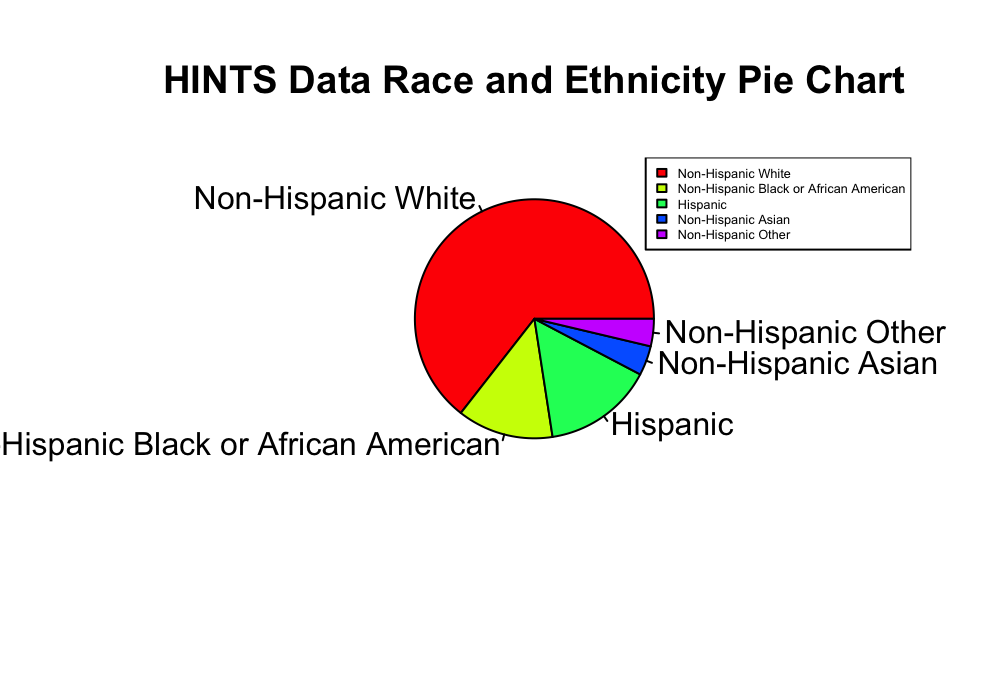

#### #Interpretation

- The pie chart for race and ethnicity shows that the predominant group seems to be non-hispanic white individuals, followed by Hispanic black or African American and Hispanic where around the same amount of the participants fall. The final group is Non hispanic other and non hispanic Asian which are the 2 lowest categories of race and ethincity.

### #Bar Plot of Quality of Care

bar_Qualitycare <- hintsdataclean$QualityCare bar_Qualitycare_table <- table(bar_Qualitycare) labels_qualitycare <- c(‘Excellent’, ‘Very Good’, ‘Good’, ‘Fair’, ‘Poor’)*#labels for the quality of care variable* barplot(bar_Qualitycare_table, names.arg=labels_qualitycare, xlab=“Quality of Care”, ylab=“Count”, col=“pink”, main=“Quality of Care Bar Chart”, border=“black”) *#creating a bar plot for the quality of care variable*

#### ##OUTPUT

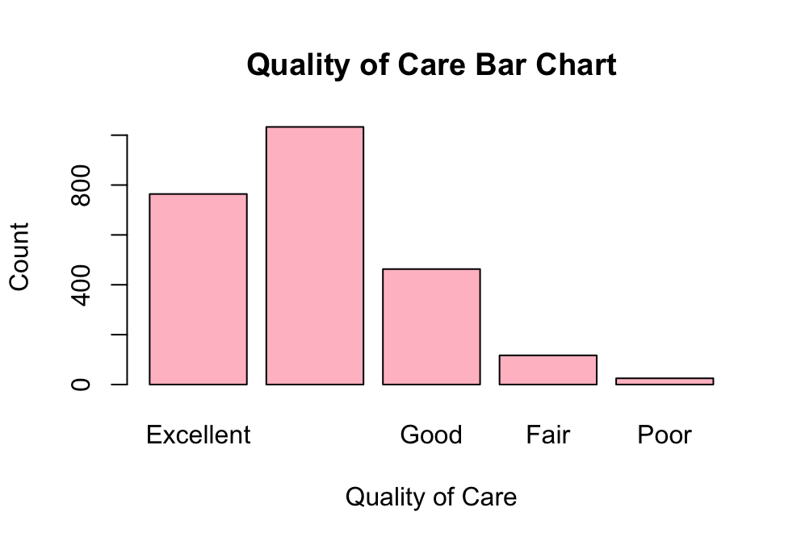

#### #Interpretation

- This bar chart shows that most participants fell into the excellent and very good groups for quality of care, indicating that most participants may have been satisfied with their quality of care.

# #B.4.2.

### #scatterplot of Age

plot(hintsdataclean$Age, main=“Age Scatterplot”)

#### ##OUTPUT

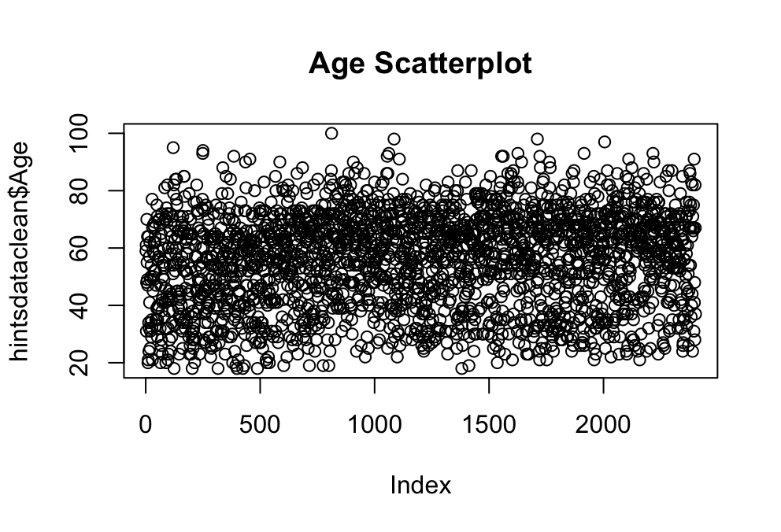

#Histogram of BMI

hist(hintsdataclean$BMI, main=“BMI Frequency”) #histogram for BMI

#### ##OUTPUT

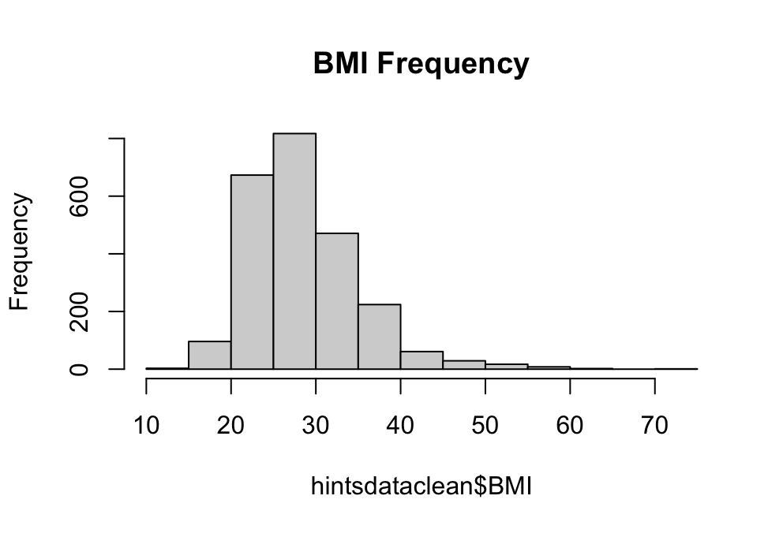

### #Interpretation

- This histogram indicates that most participants had a BMI from 20 to 35, indicating that most participants may be normal to overweight.

# #B.4.3

library(ggplot2)*#opening ggplot for the session #Histogram for Race and Ethnicity, as Pie Chart function unavailable in ggplot2*

### #Histogram Race and Ethnicity with GGplot

ggplot(hintsdataclean, aes(x=RaceEthn5)) + geom_histogram(binwidth=2, fill=“blue”, color=“black”)+ labs(title=“Histogram of Race and Ethnicity”, x = “Race and Ethnicity”, y = “Count”)

#### ##OUTPUT

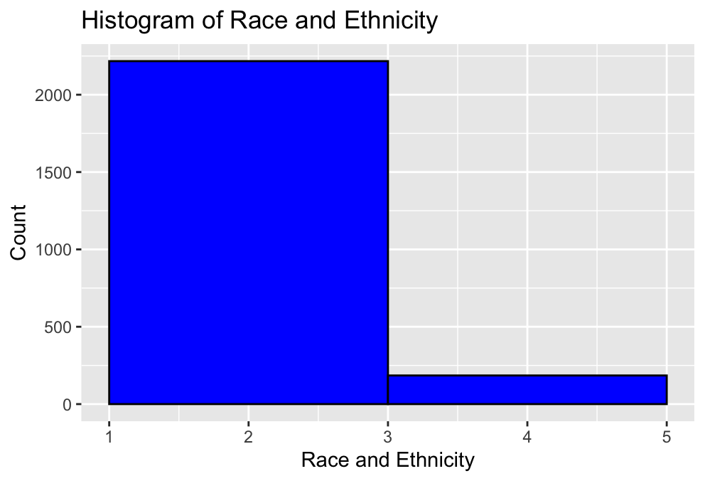

### #Bar chart for Quality of Care with GGplot

ggplot(hintsdataclean, aes(x = QualityCare, fill = QualityCare)) + *#creates a base for a bar plot with days* geom_bar() +  
labs(title = ” Distribution of Quality of Care”, *# plot title*

x = “Quality of Care”, *# x-axis label*

y = “Frequency”) + *# y-axis*

label theme_bw()

#### ##OUTPUT

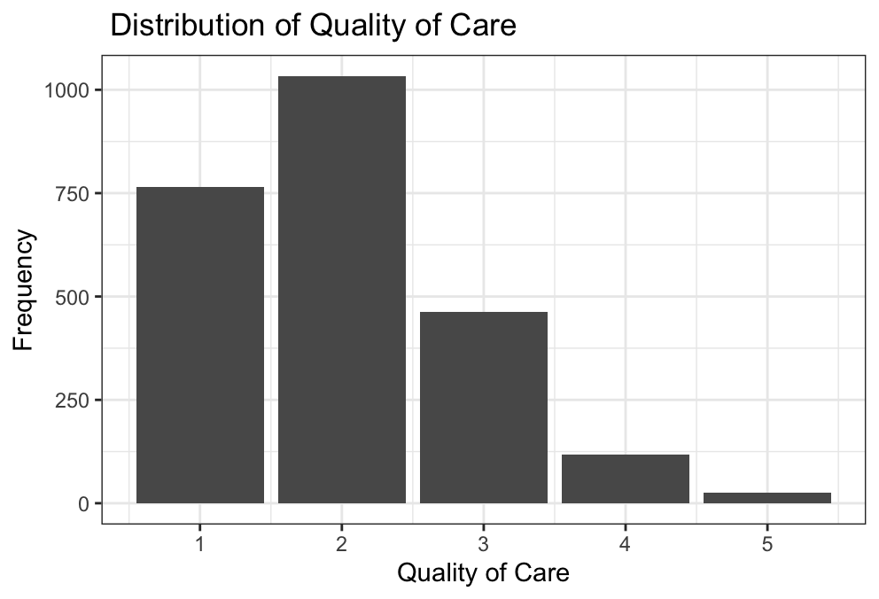

### #Histogram of BMI

ggplot(hintsdataclean, aes(x=BMI)) +

geom_histogram(binwidth=50, fill=“blue”, color=“black”)+

labs(title=“Histogram of BMI”,

x = “BMI”,

y = “Count”)

#### #OUTPUT

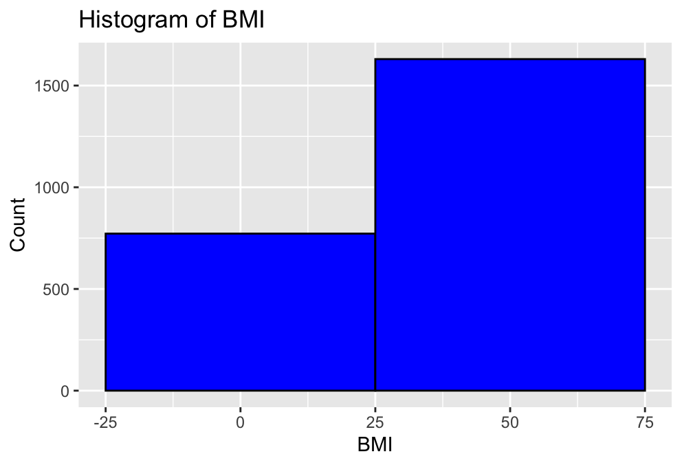

### #Scatter/boxplot Plot for Age

ggplot(hintsdataclean, aes(x=Age, fill=Age))+

geom_boxplot()+

theme(legend.position=“top”)

#### ##OUTPUT

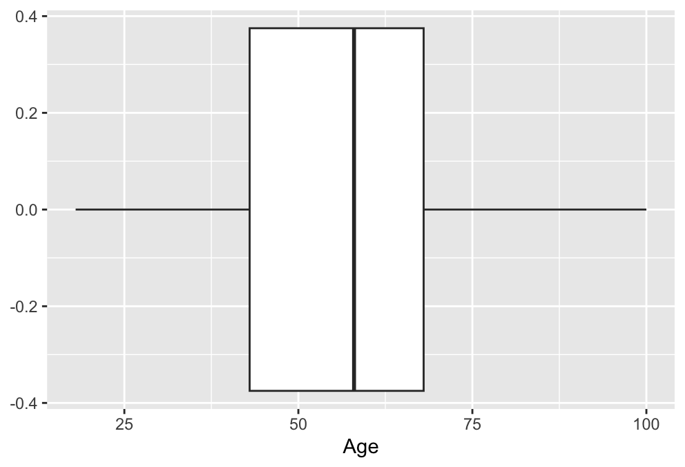

# #B.4.4

my_visual_func_I <- function(data, var) {

variable <- as.factor(data[[var]]) *#convert variable to factor* barplot(table(variable), #for the barplot function main = paste(“Distribution of”, var),

xlab = var,

ylab = “Frequency”)

}

my_visual_func_I(hintsdataclean, “QualityCare”) *#checking output*

#### ##OUTPUT

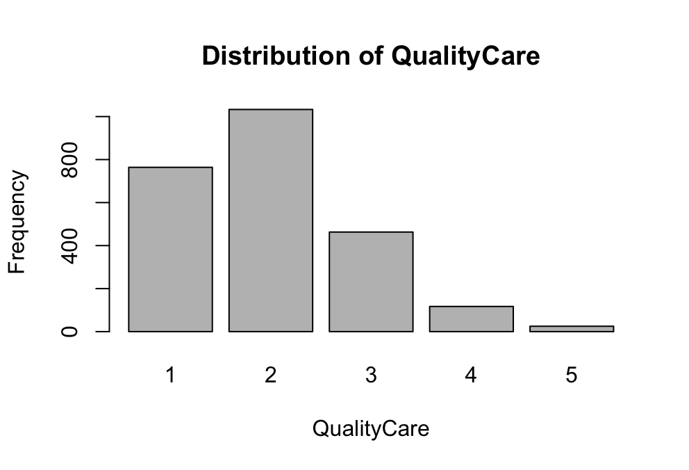

my_visual_func_I(hintsdataclean, “RaceEthn5”)#checking output

#### ##OUTPUT

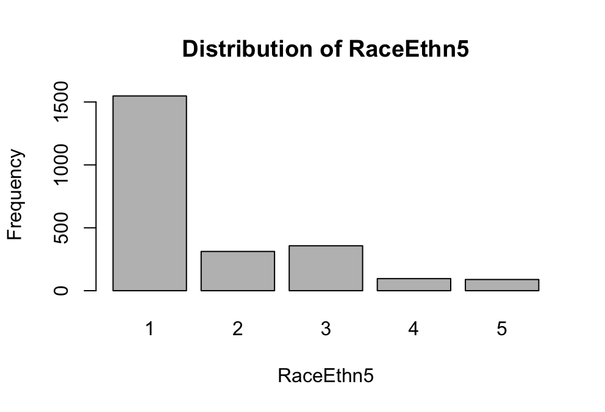

### #function number 2, continuous data

my_visual_func_II <- function(data, var) {

variable <- data[[var]] hist(variable, main = paste(“Distribution of”, var),

xlab = var,

ylab = “Frequency”)

}

my_visual_func_II(hintsdataclean, “Age”) *#checking appropriate output*

#### ##OUTPUT

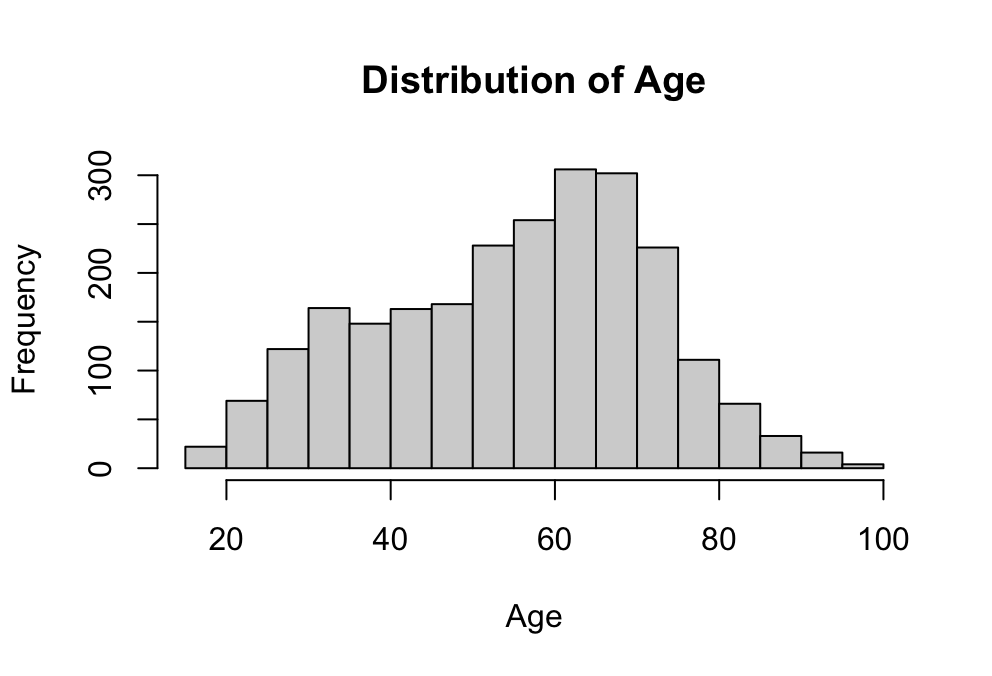

my_visual_func_II(hintsdataclean, “BMI”)*#checking output*

#### ##OUTPUT

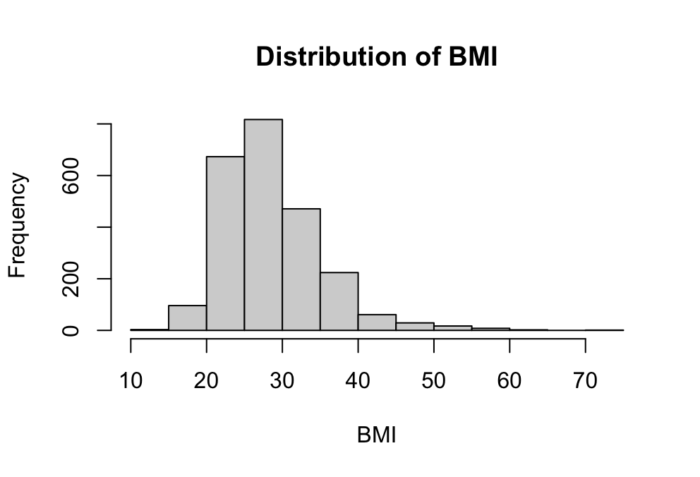